# Assignment 3: Incarceration

Matthew Kyle Pedraja

2/24/2022

## Introduction

In this report of the [Incarcerations Comma Separated Value file](https://raw.githubusercontent.com/vera-institute/incarceration-trends/master/incarceration_trends.csv), I am going to analyze the problem domain regarding prison population rates in the South, a region that is historically deeply-rooted in systemic and institutional racism. Within the data set, I am going to analyze each specific race’s prison population rate on average in order to find which race had either the highest or lowest jail or prison population rate, as well as finding the state that has the highest prison population rate within a specific year of my choosing, additionally exploring that state to provide more details regarding the prison and jail population rates for certain races mentioned in the data set. Below are the variables I will be using in order to achieve the tasks mentioned above:

- Year
  - year
- State
  - state
- Highest State Prison Population Rates in 1990
  - state_highest_prison_population_rate_1990
  - state_highest_population_rate_number
  - total_prison_pop_rate
- Race Jail Population Averages
  - aapi_jail_pop_mean
  - black_jail_pop_mean
  - latinx_jail_pop_mean
  - native_jail_pop_mean
  - white_jail_pop_mean
- Race Prison Population Averages
  - aapi_prison_pop_mean
  - black_prison_pop_mean
  - latinx_prison_pop_mean
  - native_prison_pop_mean
  - white_prison_pop_mean

Both the Race and Jail Population averages variables will be used to find the highest and lowest population rate averages for each respective institution, which will help us find the race that is being either marginalized greatly or not as marginalized in the Incarceration system of the United States, specifically in the South.

## Summary Statistics

The state that had the highest prison population rate in one county in 1990 is **TN**, with a prison population rate in that county of **4872.52**.

Black people had the highest jail population rate on average in the South, with a jail population rate of **3321.8579027**.

White people had the lowest jail population rate on average in the South, with only **398.2635681**, which is significantly smaller than the population rate of black people any other race that is listed in the data set, which showcases how marginalized minority groups are within the United States in regards to rates and proportions of the population being in jail.

Black people had the highest prison population rate on average in the South, with a prison population rate of **2571.5561285**.

Asian American and Pacific Islander people (aapi) on average had the lowest prison population in the South, with a prison population rate of **19.1590954**.

#### Additional Statistics

Native people (Native Americans) had a relatively high jail population rate average of **709.5325698**, while their prison population rate average was significantly smaller, with a population rate of **229.8542266**.

## Trend over Time chart

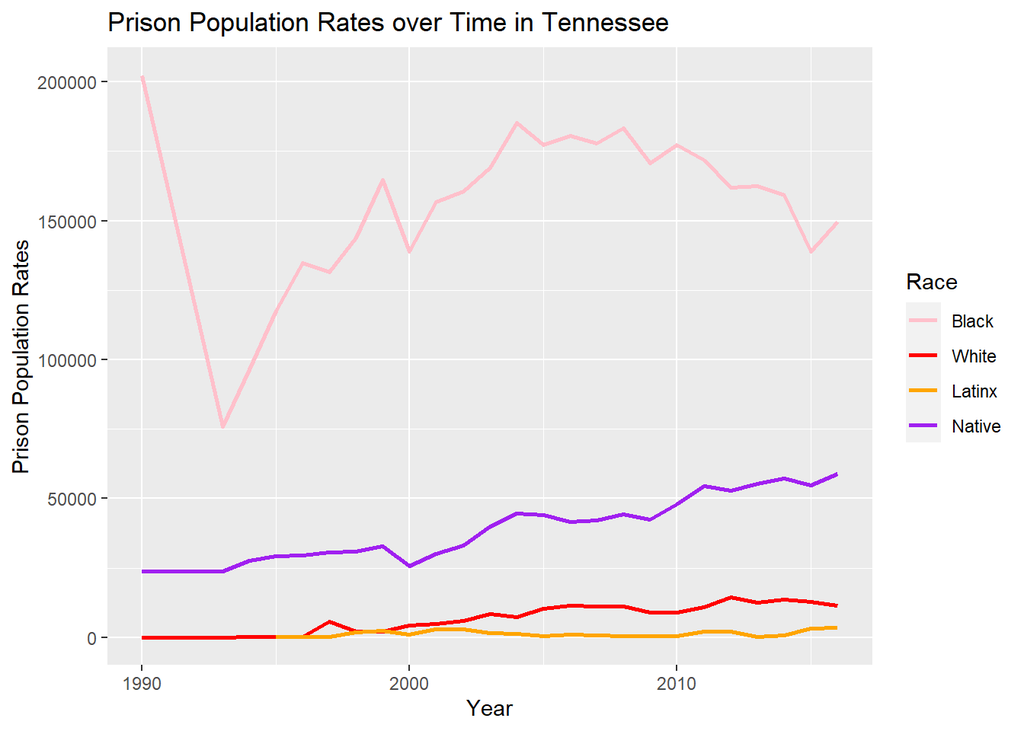